# Employment Study(Case Study 2)

Joe Schueder/Thejas Prasad

November 24, 2017

# repository: https://github.com/thejasprasad/Procrastination

##### Prepared by Joe Schueder and Thejas Prasar for “WAM (We are Motivated), Inc.

WAM Inc. would like an analysis of where to place their next set of employment training centers to market job productivity training. The primary criteria that WAM uses when creating new centers is motivation levels/procrastination levels, income averages, and education levels. They are also interested in how well developed the country of a potential center is.

The primary goal of this analysis was to understand the current climate for employment training centers around the world. This was done by analyzing employee data from several countries which included relevant procrastination scores, education, occupation, and income levels. This data was combined with the internationally recognized HDI index.

The analysis is shown below.

Data Preparation to read in and clean data was done.

```r
#1a
getwd()
```

```
## [1] "C:/Users/jjschued/Downloads/Procrastination-master/Procrastination-master/Project/Analysis"
```

```r
setwd("C:/Users/jjschued/Documents")
procrast <- read.csv(file = "Procrastination.csv", sep=",", header=TRUE)

#1a
# number of rows and columns
dim(procrast)
```

```
## [1] 4264   61
```

```r
#1b column names

#code below is for viewing all column names befoe re-lableing
#colnames(procrast)

#relabling column names for readability
colnames(procrast) <- c("Age","Gender","Kids","Edu","WorkStatus","AnnualIncome","CurrentOccup","Timeinposyr","Timeinposmn","Communitysize","Countryres","MaritalStatus","Numsons","Numdaughters","DP1","DP2","DP3","DP4","DP5","AIP1","AIP2","AIP3","AIP4","AIP5","AIP6","AIP7","AIP8","AIP9","AIP10","AIP11","AIP12","AIP13","AIP14","AIP15","GP1","GP2","GP3","GP4","GP5","GP6","GP7","GP8","GP9","GP10","GP11","GP12","GP13","GP14","GP15","GP16","GP17","GP18","GP19","GP20","SWLS1","SWLS2","SWLS3","SWLS4","SWLS5","UCONSPRO","OTHCONSPRO")

#2c i get time in service out of scientific notation
procrast$Timeinposyr <- as.integer(format(procrast$Timeinposyr, scientific = F))
# Turning 999 into NA
procrast[,"Timeinposyr"][procrast[,"Timeinposyr"]==999] <- NA
#2 c ii converting Male and Female into numeric representation
procrast$Numsons <- as.character(procrast$Numsons)

procrast$Numsons[procrast$Numsons == "Male"] <- "1"
procrast$Numsons[procrast$Numsons == "Female"] <- "2"
#2ciii
#get rid of 0 and blank and convert them to NA
procrast$Countryres <- as.character(procrast$Countryres)
procrast$Countryres[procrast$Countryres == "0"] <- "NA"
procrast$Countryres[procrast$Countryres == " "] <- "NA"

#2civ
#fix the occupation column NAs blanks, group
procrast$CurrentOccup <- as.character(procrast$CurrentOccup)
procrast$CurrentOccup[procrast$CurrentOccup == "0"] <- "NA"
procrast$CurrentOccup[procrast$CurrentOccup == "please specify"] <- "NA"
procrast$CurrentOccup = toupper(procrast$CurrentOccup)
#grouping like together now
procrast$CurrentOccup <- gsub("TEACHER.*","TEACHER", procrast$CurrentOccup)
procrast$CurrentOccup <- gsub("TECH.*","TECHNICAL", procrast$CurrentOccup)
procrast$CurrentOccup <- gsub("WRIT*","WRITER", procrast$CurrentOccup)
procrast$CurrentOccup <- gsub("STUDENT.*","STUDENT", procrast$CurrentOccup)
procrast$CurrentOccup <- gsub("*.STUDENT","STUDENT", procrast$CurrentOccup)
procrast$CurrentOccup <- gsub("SYSTEM.*","TECHNICAL", procrast$CurrentOccup)
procrast$CurrentOccup <- gsub("SOFTWARE.*","TECHNICAL", procrast$CurrentOccup)
procrast$CurrentOccup <- gsub("SELF.*","SELF EMPLOYED", procrast$CurrentOccup)
procrast$CurrentOccup <- gsub("SALES.*","SALES", procrast$CurrentOccup)
procrast$CurrentOccup <- gsub("RESEARCH.*","RESEARCH", procrast$CurrentOccup)
procrast$CurrentOccup <- gsub("REAL ESTATE.*","REAL ESTATE", procrast$CurrentOccup)
procrast$CurrentOccup <- gsub("REALTOR.*","REAL ESTATE", procrast$CurrentOccup)
procrast$CurrentOccup <- gsub("PROGRAMMER.*","TECHNICAL", procrast$CurrentOccup)
procrast$CurrentOccup <- gsub("IT .*","TECHNICAL", procrast$CurrentOccup)
procrast$CurrentOccup <- gsub("COMPUTER.*","TECHNICAL", procrast$CurrentOccup)
procrast$CurrentOccup <- gsub("DIRECTOR.*","DIRECTOR", procrast$CurrentOccup)
procrast$CurrentOccup <- gsub("FINANC.*","FINANCIAL", procrast$CurrentOccup)
procrast$CurrentOccup <- gsub("INSURANCE.*","INSURANCE", procrast$CurrentOccup)
procrast$CurrentOccup <- gsub("INFORMATION.*","TECHNICAL", procrast$CurrentOccup)
procrast$CurrentOccup <- gsub("MEDICAL.*","MEDICAL", procrast$CurrentOccup)
procrast$CurrentOccup <- gsub("LEGAL.*","LEGAL", procrast$CurrentOccup)
procrast$CurrentOccup <- gsub("LAW.*","LEGAL", procrast$CurrentOccup)
procrast$CurrentOccup <- gsub("OFFICE.*","OFFICE", procrast$CurrentOccup)
#code below can be used to view all occupations
# kable(unique(procrast$CurrentOccup), "html", padding = 2, longtable = TRUE) %>%
# kable_styling(bootstrap_options = "striped", full_width = F, position = "left")

#2d CHECK FIELD TYPES nothing wrong for now will convert later if needed
#code commendted below can be uncommented to view data typess
#str(procrast)

#2e Get the means of the procrastination indexes

procrast$dpmean <- (procrast$DP1 + procrast$DP2 + procrast$DP3 + procrast$DP4 + procrast$DP5)/5

procrast$aipmean <- (procrast$AIP1 + procrast$AIP2 +procrast$AIP3 +procrast$AIP4 +procrast$AIP5 +procrast$AIP6 +procrast$AIP7 +procrast$AIP8 +procrast$AIP9 +procrast$AIP10 +procrast$AIP11 +procrast$AIP12 +procrast$AIP13 +procrast$AIP14 + procrast$AIP15) /15

procrast$gpmean <- (procrast$GP1 + procrast$GP2 + procrast$GP3 + procrast$GP4 + procrast$GP5 + procrast$GP6 + procrast$GP7 + procrast$GP8 + procrast$GP9 + procrast$GP10 + procrast$GP11 + procrast$GP12 + procrast$GP13 + procrast$GP14 + procrast$GP15 + procrast$GP16 + procrast$GP17 + procrast$GP18 + procrast$GP19 + procrast$GP20)/20

procrast$swlsmean <- (procrast$SWLS1 + procrast$SWLS2 + procrast$SWLS3 + procrast$SWLS4 + procrast$SWLS5)/5

#code below for viewing table contents
kable(head(procrast), "html", padding = 2, longtable = TRUE) %>%
kable_styling(bootstrap_options = "striped", full_width = F, position = "left")
```

| Age | Gender | Kids | Edu | WorkStatus | AnnualIncome | CurrentOccup | Timeinposyr | Timeinposmn | Communitysize | Countryres | MaritalStatus | Numsons | Numdaughters | DP1 | DP2 | DP3 | DP4 | DP5 | AIP1 | AIP2 | AIP3 | AIP4 | AIP5 | AIP6 | AIP7 | AIP8 | AIP9 | AIP10 | AIP11 | … |
| --- | --- | --- | --- | --- | --- | --- | --- | --- | --- | --- | --- | --- | --- | --- | --- | --- | --- | --- | --- | --- | --- | --- | --- | --- | --- | --- | --- | --- | --- | --- |
| 67.5 | Male | Yes Kids | ma | retired | 25000 |  | 9 | 0 | Large-City | El Salvador | Divorced | 0 | 5 | 3 | 1 | 1 | 1 | 1 | 1 | 1 | 1 | 1 | 1 | 1 | 1 | 1 | 5 | 1 | 1 | … |
| 45.0 | Male | Yes Kids | deg | part-time | 35000 |  | 0 | 0 | Village | Bolivia | Married | 1 | 1 | 3 | 4 | 3 | 3 | 3 | 3 | 1 | 4 | 3 | 3 | 4 | 3 | 3 | 3 | 3 | 4 | … |
| 19.0 | Female | No Kids | dip | student | NA |  | 0 | 0 | Large Town | Cyprus | Single | 0 | 0 | 5 | 5 | 2 | 3 | 3 | 5 | 4 | 4 | 5 | 5 | 5 | 5 | 4 | 5 | 5 | 4 | … |
| 37.5 | Male | Yes Kids | ma | full-time | 45000 |  | 14 | 0 | Large Town | Czech Republic | Married | 0 | 1 | 3 | 3 | 3 | 3 | 3 | 2 | 1 | 4 | 3 | 5 | 3 | 4 | 5 | 4 | 5 | 4 | … |
| 28.0 | Female | No Kids | deg | full-time | 35000 |  | 1 | 0 | Village | Czech Republic | Single | 0 | 0 | 3 | 3 | 2 | 1 | 1 | 1 | 1 | 3 | 3 | 2 | 2 | 2 | 2 | 1 | 1 | 2 | … |
| 23.0 | Female | No Kids | deg | full-time | 15000 |  | 1 | 0 | Small Town | Czech Republic | Single | 0 | 0 | 3 | 4 | 3 | 2 | 2 | 2 | 5 | 5 | 5 | 5 | 3 | 5 | 4 | 4 | 5 | 3 | … |

```r
## 3a Getting data about human development index from wikipedia

URL <- 'https://en.wikipedia.org/wiki/List_of_countries_by_Human_Development_Index#Complete_list_of_countries'

#very high index countries
  HDIURL <- URL %>%
  read_html() %>%
  html_nodes(xpath='//*[@id="mw-content-text"]/div/div[5]/table') %>%
  html_table(fill = TRUE)
  HDITABVH <- HDIURL[[1]]

#labeling useful columns
colnames(HDITABVH)[1:5] <- c("Rank", "RankChng", "Country", "HDI", "HDICHNG")

#limiting columns and categorizing this table
HDITABVHS <- HDITABVH[1:5]

HDITABVHS$HDICAT <- "Very High"

#getting rid of extra rows
HDITABVHS <- HDITABVHS[-c(1, 2, 3, 30, 31), ]

#high index countries
  HDIURL <- URL %>%
  read_html() %>%
  html_nodes(xpath='//*[@id="mw-content-text"]/div/div[6]/table') %>%
  html_table(fill = TRUE)
  HDITABH <- HDIURL[[1]]

#change column names

colnames(HDITABH)[1:5] <- c("Rank", "RankChng", "Country", "HDI", "HDICHNG")
HDITABHS <- HDITABH[1:5]
HDITABHS$HDICAT <- "High"

#getting rid of extra rows including one labled world which is not a country
HDITABHS <- HDITABHS[-c(1, 2, 3, 32, 33, 56), ]

#medium index countries
  HDIURL <- URL %>%
  read_html() %>%
  html_nodes(xpath='//*[@id="mw-content-text"]/div/div[7]/table') %>%
  html_table(fill = TRUE)
  HDITABM <- HDIURL[[1]]
colnames(HDITABM)[1:5] <- c("Rank", "RankChng", "Country", "HDI", "HDICHNG")

HDITABMS <- HDITABM[1:5]
HDITABMS$HDICAT <- "Medium"

#getting rid of extra rows
HDITABMS <- HDITABMS[-c(1, 2, 3, 24, 25), ]

#low index countries
  HDIURL <- URL %>%
  read_html() %>%
  html_nodes(xpath='//*[@id="mw-content-text"]/div/div[8]/table') %>%
  html_table(fill=TRUE)
  HDITABL <- HDIURL[[1]]

  colnames(HDITABL)[1:5] <- c("Rank", "RankChng", "Country", "HDI", "HDICHNG")
  HDITABLS <- HDITABL[1:5]
  HDITABLS$HDICAT <- "Low"

#getting rid of extra rows
HDITABLS <- HDITABLS[-c(1, 2, 3, 25, 26), ]

# The commented code below was used to explore the data to eliminate bad rows
# kable(HDITABVHS, "html", padding = 2, longtable = TRUE, row.names = TRUE) %>%
# kable_styling(bootstrap_options = "striped", full_width = F, position = "left")
#
# kable(HDITABHS, "html", padding = 2, longtable = TRUE, row.names = TRUE) %>%
# kable_styling(bootstrap_options = "striped", full_width = F, position = "left")
#
# kable(HDITABMS, "html", padding = 2, longtable = TRUE, row.names = TRUE) %>%
# kable_styling(bootstrap_options = "striped", full_width = F, position = "left")
#
# kable(HDITABLS, "html", padding = 2, longtable = TRUE, row.names = TRUE) %>%
# kable_styling(bootstrap_options = "striped", full_width = F, position = "left")

#3b merge all the tables together
hdicomb <- rbind(HDITABVHS, HDITABHS, HDITABMS, HDITABLS)

kable(hdicomb, "html", padding = 2, longtable = TRUE, row.names = TRUE) %>%
kable_styling(bootstrap_options = "striped", full_width = F, position = "left")
```

Rank

RankChng

Country

HDI

HDICHNG

HDICAT

4

1

Norway

0.949

0.001

Very High

5

2

Australia

0.939

0.002

Very High

6

2

Switzerland

0.939

0.001

Very High

7

4

Germany

0.926

0.002

Very High

8

5

Denmark

0.925

0.002

Very High

9

5

Singapore

0.925

0.001

Very High

10

7

Netherlands

0.924

0.001

Very High

11

8

Ireland

0.923

0.003

Very High

12

9

Iceland

0.921

0.002

Very High

13

10

Canada

0.920

0.001

Very High

14

10

United States

0.920

0.002

Very High

15

12

Hong Kong

0.917

0.001

Very High

16

13

New Zealand

0.915

0.002

Very High

17

14

Sweden

0.913

0.004

Very High

18

15

Liechtenstein

0.912

0.001

Very High

19

16

United Kingdom

0.909

0.001

Very High

20

17

Japan

0.903

0.001

Very High

21

18

South Korea

0.901

0.002

Very High

22

19

Israel

0.899

0.001

Very High

23

20

Luxembourg

0.898

0.002

Very High

24

21

France

0.897

0.003

Very High

25

22

Belgium

0.896

0.001

Very High

26

23

Finland

0.895

0.002

Very High

27

24

Austria

0.893

0.001

Very High

28

25

Slovenia

0.890

0.002

Very High

29

26

Italy

0.887

0.006

Very High

32

27

Spain

0.884

0.002

Very High

33

28

Czech Republic

0.878

0.003

Very High

34

29

Greece

0.866

0.001

Very High

35

30

Brunei

0.865

0.001

Very High

36

30

Estonia

0.865

0.002

Very High

37

32

Andorra

0.858

0.001

Very High

38

33

Cyprus

0.856

0.002

Very High

39

33

Malta

0.856

0.003

Very High

40

33

Qatar

0.856

0.001

Very High

41

36

Poland

0.855

0.003

Very High

42

37

Lithuania

0.848

0.002

Very High

43

38

Chile

0.847

0.002

Very High

44

38

Saudi Arabia

0.847

0.002

Very High

45

40

Slovakia

0.845

0.003

Very High

46

41

Portugal

0.843

0.002

Very High

47

42

United Arab Emirates

0.840

0.004

Very High

48

43

Hungary

0.836

0.002

Very High

49

44

Latvia

0.830

0.002

Very High

50

45

Argentina

0.827

0.001

Very High

51

45

Croatia

0.827

0.004

Very High

52

47

Bahrain

0.824

0.001

Very High

53

48

Montenegro

0.807

0.003

Very High

54

49

Russia

0.804

0.001

Very High

55

50

Romania

0.802

0.004

Very High

56

51

Kuwait

0.800

0.001

Very High

410

52

Belarus

0.796

0.002

High

510

52

Oman

0.796

0.001

High

62

54

Barbados

0.795

0.001

High

71

54

Uruguay

0.795

0.001

High

81

56

Bulgaria

0.794

0.002

High

91

56

Kazakhstan

0.794

0.001

High

101

58

Bahamas

0.792

0.002

High

111

59

Malaysia

0.789

0.010

High

121

60

Palau

0.788

0.005

High

131

60

Panama

0.788

0.003

High

141

62

Antigua and Barbuda

0.786

0.002

High

151

63

Seychelles

0.782

0.001

High

161

64

Mauritius

0.781

0.002

High

171

65

Trinidad and Tobago

0.780

0.001

High

181

66

Costa Rica

0.776

0.001

High

191

66

Serbia

0.776

0.001

High

201

68

Cuba

0.775

0.003

High

211

69

Iran

0.774

High

221

70

Georgia

0.769

0.001

High

231

71

Turkey

0.767

0.003

High

241

71

Venezuela

0.767

0.002

High

251

73

Sri Lanka

0.766

0.002

High

261

74

Saint Kitts and Nevis

0.765

0.003

High

271

75

Albania

0.764

0.002

High

281

76

Lebanon

0.763

High

291

77

Mexico

0.762

0.004

High

30

78

Azerbaijan

0.759

0.001

High

31

79

Brazil

0.754

High

341

79

Grenada

0.754

0.003

High

351

81

Bosnia and Herzegovina

0.750

0.003

High

361

82

Macedonia

0.748

0.002

High

371

83

Algeria

0.745

0.002

High

381

84

Armenia

0.743

0.002

High

391

84

Ukraine

0.743

0.005

High

401

86

Jordan

0.741

High

411

87

Peru

0.740

0.003

High

421

87

Thailand

0.740

0.003

High

431

89

Ecuador

0.739

High

441

90

China

0.738

0.010

High

451

91

Fiji

0.736

0.002

High

461

92

Mongolia

0.735

0.002

High

471

92

Saint Lucia

0.735

High

481

94

Jamaica

0.730

0.001

High

491

95

Colombia

0.727

0.003

High

501

96

Dominica

0.726

0.002

High

511

97

Suriname

0.725

0.002

High

521

97

Tunisia

0.725

0.002

High

531

99

Dominican Republic

0.722

0.004

High

541

99

Saint Vincent and the Grenadines

0.722

0.002

High

551

101

Tonga

0.721

0.003

High

57

102

Libya

0.716

0.003

High

58

103

Belize

0.706

High

59

104

Samoa

0.704

0.002

High

60

105

Maldives

0.701

High

61

105

Uzbekistan

0.701

0.004

High

412

107

Moldova

0.699

0.002

Medium

512

108

Botswana

0.698

Medium

63

109

Gabon

0.697

0.003

Medium

72

110

Paraguay

0.693

0.001

Medium

82

111

Egypt

0.691

0.003

Medium

92

111

Turkmenistan

0.691

0.003

Medium

102

113

Indonesia

0.689

0.003

Medium

112

114

Palestine

0.684

0.006

Medium

122

115

Vietnam

0.683

0.005

Medium

132

116

Philippines

0.682

0.003

Medium

142

117

El Salvador

0.680

0.002

Medium

152

118

Bolivia

0.674

0.003

Medium

162

119

South Africa

0.666

0.001

Medium

172

120

Kyrgyzstan

0.664

0.002

Medium

182

121

Iraq

0.649

Medium

192

122

Cape Verde

0.648

0.002

Medium

202

123

Morocco

0.647

0.002

Medium

212

124

Nicaragua

0.645

0.003

Medium

222

125

Guatemala

0.640

0.003

Medium

232

125

Namibia

0.640

0.003

Medium

262

127

Guyana

0.638

Medium

272

127

Micronesia

0.638

0.001

Medium

282

129

Tajikistan

0.627

0.002

Medium

292

130

Honduras

0.625

0.002

Medium

301

131

India

0.624

0.009

Medium

311

132

Bhutan

0.607

0.003

Medium

321

133

Timor Leste

0.605

0.002

Medium

331

134

Vanuatu

0.597

0.001

Medium

342

135

Congo, Republic of the

0.592

0.003

Medium

352

135

Equatorial Guinea

0.592

0.010

Medium

362

137

Kiribati

0.588

0.002

Medium

372

138

Laos

0.586

0.004

Medium

382

139

Bangladesh

0.579

0.004

Medium

392

139

Ghana

0.579

0.004

Medium

402

139

Zambia

0.579

0.003

Medium

413

142

São Tomé and Príncipe

0.574

0.009

Medium

422

143

Cambodia

0.563

0.005

Medium

432

144

Nepal

0.558

0.003

Medium

442

145

Myanmar

0.556

0.004

Medium

452

146

Kenya

0.555

0.005

Medium

462

147

Pakistan

0.550

0.002

Medium

414

148

Swaziland

0.541

Low

513

149

Syria

0.536

0.017

Low

64

150

Angola

0.533

0.002

Low

73

151

Tanzania

0.531

0.012

Low

83

152

Nigeria

0.527

0.002

Low

93

153

Cameroon

0.518

0.004

Low

103

154

Papua New Guinea

0.516

0.001

Low

113

154

Zimbabwe

0.516

0.009

Low

123

156

Solomon Islands

0.515

0.002

Low

133

157

Mauritania

0.513

Low

143

158

Madagascar

0.512

0.001

Low

153

159

Rwanda

0.498

0.005

Low

163

160

Comoros

0.497

0.001

Low

173

160

Lesotho

0.497

0.002

Low

183

162

Senegal

0.494

0.003

Low

193

163

Haiti

0.493

0.003

Low

203

163

Uganda

0.493

0.005

Low

213

165

Sudan

0.490

0.002

Low

223

166

Togo

0.487

0.003

Low

233

167

Benin

0.485

0.004

Low

242

168

Yemen

0.482

0.017

Low

273

169

Afghanistan

0.479

Low

283

170

Malawi

0.476

0.003

Low

293

171

Côte d’Ivoire

0.474

0.008

Low

302

172

Djibouti

0.473

0.003

Low

312

173

Gambia

0.452

0.002

Low

322

174

Ethiopia

0.448

0.007

Low

332

175

Mali

0.442

0.004

Low

343

176

Congo, Democratic Republic of the

0.435

0.010

Low

353

177

Liberia

0.427

Low

363

178

Guinea Bissau

0.424

0.003

Low

373

179

Eritrea

0.420

0.002

Low

383

179

Sierra Leone

0.420

0.011

Low

393

181

Mozambique

0.418

0.004

Low

403

181

South Sudan

0.418

0.003

Low

415

183

Guinea

0.414

Low

423

184

Burundi

0.404

0.002

Low

433

185

Burkina Faso

0.402

0.003

Low

443

186

Chad

0.396

0.002

Low

453

187

Niger

0.353

0.002

Low

463

188

Central African Republic

0.352

0.005

Low

```r
dim(hdicomb)
```

```
## [1] 188   6
```

```r
#3c
#write table to csv(6a)
#setwd("C:/Users/jjschued/Documents")
write.table(hdicomb, file = "hdicomb.csv", col.names = TRUE, row.names = FALSE, sep =",")

#merge procrastination and and hdicomb
colnames(hdicomb)[3] <- "Countryres"
procrastcomb <- merge(procrast, hdicomb, by=c("Countryres"), all = FALSE )



kable(head(procrastcomb), "html", padding = 2, longtable = TRUE, row.names = TRUE) %>%
kable_styling(bootstrap_options = "striped", full_width = F, position = "left")
```

|  | Countryres | Age | Gender | Kids | Edu | WorkStatus | AnnualIncome | CurrentOccup | Timeinposyr | Timeinposmn | Communitysize | MaritalStatus | Numsons | Numdaughters | DP1 | DP2 | DP3 | DP4 | DP5 | AIP1 | AIP2 | AIP3 | AIP4 | AIP5 | AIP6 | AIP7 | AIP8 | AIP9 | AIP10 | … |
| --- | --- | --- | --- | --- | --- | --- | --- | --- | --- | --- | --- | --- | --- | --- | --- | --- | --- | --- | --- | --- | --- | --- | --- | --- | --- | --- | --- | --- | --- | --- |
| 1 | Afghanistan | 55.0 | Male | Yes Kids | ma | full-time | 150000 |  | 0 | 0 | Large Town | Married | 4 | 2 | 4 | 4 | 4 | 3 | 3 | 3 | 4 | 5 | 4 | 3 | 4 | 3 | 5 | 4 | 3 | … |
| 2 | Afghanistan | 80.0 | Female | No Kids | grade | unemployed | 10000 |  | 0 | 0 | Medium-Sized | Single | 0 | 0 | 2 | 3 | 2 | 3 | 5 | 2 | 2 | 3 | 4 | 2 | 2 | 2 | 1 | 1 | 3 | … |
| 3 | Afghanistan | 55.0 | Male | No Kids | deg | full-time | 87500 |  | 0 | 6 | Large Town | Married | 0 | 0 | 3 | 3 | 3 | 4 | 3 | 3 | 2 | 2 | 2 | 3 | 2 | 3 | 3 | 2 | 3 | … |
| 4 | Afghanistan | 55.0 | Female | Yes Kids | deg | full-time | 10000 |  | 7 | 0 | Village | Divorced | 4 | 0 | 4 | 3 | 4 | 3 | 2 | 1 | 2 | 1 | 4 | 3 | 5 | 4 | 4 | 3 | 3 | … |
| 5 | Albania | 45.0 | Female | No Kids | ltuni | full-time | 150000 |  | 0 | 0 | Large Town | Single | 0 | 0 | 3 | 3 | 5 | 3 | 3 | 3 | 1 | 2 | 1 | 2 | 2 | 2 | 2 | 1 | 2 | … |
| 6 | Albania | 67.5 | Male | Yes Kids | deg | part-time | 87500 | MEDIA CONSULTANT | 4 | 0 | Large-City | Divorced | 0 | 2 | 4 | 3 | 2 | 2 | 1 | 4 | 1 | 5 | 1 | 2 | 1 | 1 | 3 | 2 | 3 | … |

```r
#4a remove everone under 18 and over 65 since this is for a work analysis since people typically stop working at 65

procrastcomb <- procrastcomb[procrastcomb$Age > 18, ]
procrastcomb <- procrastcomb[procrastcomb$Age < 65, ]

#convert HDI to numeric

procrastcomb$HDI <- as.numeric(format(procrastcomb$HDI, scientific = F))
#write table to csv(6b)
write.table(procrastcomb, file = "procrastcomb.csv", col.names = TRUE, row.names = FALSE, sep =",")
```

```r
# 4b summary statistics of procrastcomb
sumtable <- summary(procrastcomb$Age)
Statistics <- c("Min.", "1st Qu.",  "Median", "Mean", "3rd Qu.", "Max.", "NA's" )
Age <- c(sumtable[1], sumtable[2],  sumtable[3], sumtable[4], sumtable[5], sumtable[6], sumtable[7] )

sumtable <- summary(procrastcomb$AnnualIncome)
Income <- c(sumtable[1], sumtable[2],  sumtable[3], sumtable[4], sumtable[5], sumtable[6], sumtable[7] )

sumtable <- summary(procrastcomb$HDI)
HDI <- c(sumtable[1], sumtable[2],  sumtable[3], sumtable[4], sumtable[5], sumtable[6], sumtable[7] )
sumtable <- summary(procrastcomb$aipmean)
AIPmean <- c(sumtable[1], sumtable[2],  sumtable[3], sumtable[4], sumtable[5], sumtable[6], sumtable[7] )
sumtable <- summary(procrastcomb$dpmean)
DPmean <- c(sumtable[1], sumtable[2],  sumtable[3], sumtable[4], sumtable[5], sumtable[6], sumtable[7] )
sumtable <- summary(procrastcomb$gpmean)
GPmean <- c(sumtable[1], sumtable[2],  sumtable[3], sumtable[4], sumtable[5], sumtable[6], sumtable[7] )
sumtable <- summary(procrastcomb$swlsmean)
SSWLSmean <- c(sumtable[1], sumtable[2],  sumtable[3], sumtable[4], sumtable[5], sumtable[6], sumtable[7] )
sumdf <- data.frame(Statistics, Age, Income, HDI, AIPmean, DPmean, GPmean, SSWLSmean)
kable(sumdf, "html", padding = 2, longtable = TRUE, row.names = FALSE, digits = 2) %>%
kable_styling(bootstrap_options = "striped", full_width = F, position = "left")
```

| Statistics | Age | Income | HDI | AIPmean | DPmean | GPmean | SSWLSmean |
| --- | --- | --- | --- | --- | --- | --- | --- |
| Min. | 19.00 | 10000.00 | 0.48 | 1.00 | 1.00 | 1.00 | 1.00 |
| 1st Qu. | 28.00 | 15000.00 | 0.92 | 2.40 | 2.40 | 2.80 | 2.40 |
| Median | 32.50 | 45000.00 | 0.92 | 3.00 | 3.00 | 3.30 | 3.00 |
| Mean | 36.42 | 58449.64 | 0.91 | 2.99 | 3.06 | 3.26 | 3.03 |
| 3rd Qu. | 45.00 | 67500.00 | 0.92 | 3.60 | 3.80 | 3.75 | 3.80 |
| Max. | 55.00 | 250000.00 | 0.95 | 5.00 | 5.00 | 5.00 | 5.00 |
| NA’s | 6.00 | 324.00 | 6.00 | 6.00 | 6.00 | 6.00 | 6.00 |

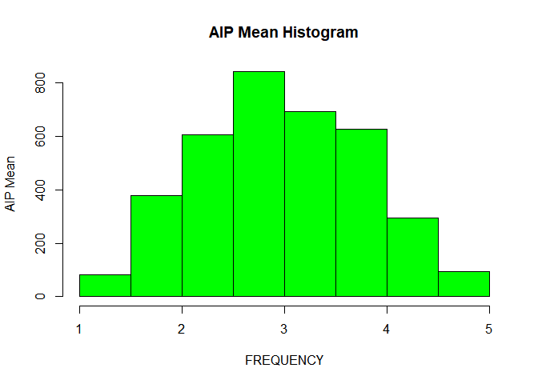

```r
#Histograms of two vairables above.  AIP is very much a bell shape curve and evenly distributed, while income is a left skewed curve with most falling on the lower end of the income scale
hist(procrastcomb$aipmean, col="Green", ylab ="AIP Mean", xlab
="FREQUENCY", main = "AIP Mean Histogram")
```

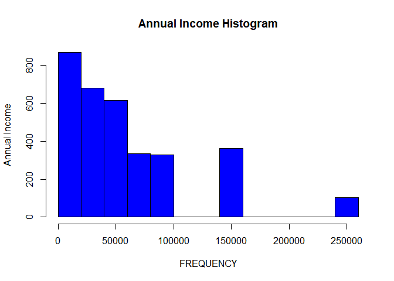

```r
hist(procrastcomb$AnnualIncome, col="Blue", ylab ="Annual Income", xlab
="FREQUENCY", main = "Annual Income Histogram")
```

```r
## 4c frequencies of Gender, work Status, Occupation
Gendersum <- count(procrastcomb, 'Gender')
WStatussm <- count(procrastcomb, 'WorkStatus')
OccuStSm <- count(procrastcomb, 'CurrentOccup')

colnames(Gendersum)[2] <- "Frequency"
colnames(WStatussm)[2] <- "Frequency"
colnames(OccuStSm)[2] <- "Frequency"

OccuStSm <- OccuStSm[order(-OccuStSm$Frequency),]

kable(Gendersum, "html", padding = 2, longtable = TRUE, row.names = FALSE) %>%
kable_styling(bootstrap_options = "striped", full_width = F, position = "left")
```

| Gender | Frequency |
| --- | --- |
|  | 5 |
| Female | 2088 |
| Male | 1521 |
| NA | 6 |

```r
kable(WStatussm, "html", padding = 2, longtable = TRUE, row.names = FALSE) %>%
kable_styling(bootstrap_options = "striped", full_width = F, position = "left")
```

| WorkStatus | Frequency |
| --- | --- |
|  | 21 |
| full-time | 2115 |
| part-time | 413 |
| retired | 56 |
| student | 777 |
| unemployed | 232 |
| NA | 6 |

```r
kable(head(OccuStSm, 20), "html", padding = 2, longtable = TRUE, row.names = FALSE) %>%
kable_styling(bootstrap_options = "striped", full_width = F, position = "left")
```

| CurrentOccup | Frequency |
| --- | --- |
|  | 1825 |
| NA | 526 |
| TECHNICAL | 86 |
| TEACHER | 71 |
| ATTORNEY | 46 |
| COLLEGE PROFESSOR | 40 |
| MANAGER | 30 |
| RESEARCH | 30 |
| ENGINEER | 29 |
| EDITOR | 21 |
| FINANCIAL | 21 |
| MARKETING | 20 |
| DIRECTOR | 17 |
| WRITERER | 17 |
| UNEMPLOYED | 16 |
| HOUSWIFE | 15 |
| ASSISTANT PROFESSOR | 13 |
| DOCTOR; PHYSICIAN | 13 |
| NURSE | 13 |
| SALES | 13 |

```r
# 4d Count of respondents by country
Countrycnt <- count(procrastcomb, 'Countryres')
colnames(Countrycnt)[2] <- "Frequency"
Countrycnt <- Countrycnt[order(-Countrycnt$Frequency),]
kable(Countrycnt, "html", padding = 2, longtable = TRUE, row.names = FALSE) %>%
kable_styling(bootstrap_options = "striped", full_width = F, position = "left")
```

| Countryres | Frequency |
| --- | --- |
| United States | 2598 |
| Canada | 237 |
| United Kingdom | 171 |
| Australia | 98 |
| India | 78 |
| Italy | 55 |
| Germany | 36 |
| Brazil | 19 |
| Ireland | 17 |
| Netherlands | 16 |
| Sweden | 15 |
| Norway | 14 |
| France | 13 |
| Japan | 13 |
| Spain | 13 |
| Finland | 12 |
| New Zealand | 12 |
| South Africa | 12 |
| China | 11 |
| Philippines | 11 |
| Switzerland | 10 |
| Belgium | 9 |
| Denmark | 9 |
| Greece | 9 |
| Mexico | 9 |
| Turkey | 9 |
| Hong Kong | 7 |
| Portugal | 7 |
| Slovenia | 6 |
| NA | 6 |
| Poland | 5 |
| Romania | 5 |
| Chile | 4 |
| Croatia | 4 |
| Malaysia | 4 |
| Singapore | 4 |
| Afghanistan | 3 |
| Algeria | 3 |
| Austria | 3 |
| Czech Republic | 3 |
| Ecuador | 3 |
| Uruguay | 3 |
| Argentina | 2 |
| Bulgaria | 2 |
| Ghana | 2 |
| Iran | 2 |
| Malta | 2 |
| Peru | 2 |
| Saudi Arabia | 2 |
| Ukraine | 2 |
| Venezuela | 2 |
| Albania | 1 |
| Andorra | 1 |
| Bahamas | 1 |
| Barbados | 1 |
| Bolivia | 1 |
| Botswana | 1 |
| Cyprus | 1 |
| Dominican Republic | 1 |
| Egypt | 1 |
| Guyana | 1 |
| Hungary | 1 |
| Iceland | 1 |
| Kenya | 1 |
| Lithuania | 1 |
| Luxembourg | 1 |
| Macedonia | 1 |
| Myanmar | 1 |
| Nicaragua | 1 |
| Pakistan | 1 |
| Panama | 1 |
| Qatar | 1 |
| Russia | 1 |
| South Korea | 1 |
| Sri Lanka | 1 |
| Thailand | 1 |
| Vietnam | 1 |

```r
#str(procrastcomb)
#4e matched perceptions
procrastcomb$UCONSPRO <- as.character(procrastcomb$UCONSPRO )
procrastcomb$OTHCONSPRO <- as.character(procrastcomb$OTHCONSPRO)
#where repsonses match
procrastmatch <- procrastcomb[which(procrastcomb$UCONSPRO == procrastcomb$OTHCONSPRO), ]
promatchsum <- count(procrastmatch, 'UCONSPRO')
colnames(promatchsum)[1] <- "Responses"
colnames(promatchsum)[2] <- "#Matches"
kable(promatchsum, "html", padding = 2, longtable = TRUE, row.names = FALSE, caption ="Personal perception procrastination responses that match others perceptions") %>%
kable_styling(bootstrap_options = "striped", full_width = F, position = "left")
```

Personal perception procrastination responses that match others perceptions

| Responses | #Matches |
| --- | --- |
|  | 4 |
| no | 405 |
| yes | 2151 |

```r
#where responses do not match
procrastmismatch <- procrastcomb[which(procrastcomb$UCONSPRO != procrastcomb$OTHCONSPRO), ]
promismatchsum <- count(procrastmismatch, 'UCONSPRO')
colnames(promismatchsum)[1] <- "Responses"
colnames(promismatchsum)[2] <- "#MisMatches"
kable(promismatchsum, "html", padding = 2, longtable = TRUE, row.names = FALSE, caption ="Personal perception procrastination responses that do not match others perceptions") %>%
kable_styling(bootstrap_options = "striped", full_width = F, position = "left")
```

Personal perception procrastination responses that do not match others perceptions

| Responses | #MisMatches |
| --- | --- |
|  | 1 |
| no | 48 |
| yes | 1005 |

To get to where the greatest need is for the productivity training analysis must be shown at the country level. When top most procrastinating countries compared by two different procrastination survey indices there emerges that there are eight countries that are in both indices. These are the Dominican Republic, Qatar, Panama, Ecuador, Sri Lanka, Turkey, Uruguay, and Iran. Many of these countries are in the HDI Category high. This seems like they are countries that would benefit most from the centers. If, the company wished to focus more on countries with higher disposable incomes it might be best to limit the data to HDI category Very High. If this restriction is made the top countries would be Qatar, Austria, Poland, Germany, Hong Kong, and Iceland.

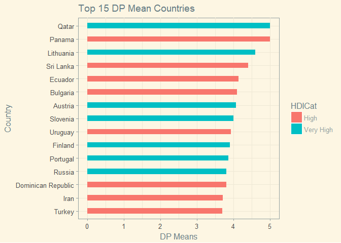

```r
#5b barchart of top 15 dp

top15dp <- aggregate(procrastcomb[, 62], by = list(procrastcomb$Countryres, procrastcomb$HDICAT), mean, na.rm=TRUE)
colnames(top15dp) <- c("Country", "HDICat", "DPmean")

#get the dp countries for very high hdi
top15dpvh <- subset(top15dp, HDICat=='Very High' )
top15dpvh <- top15dpvh[order(-top15dpvh$DPmean),]
#top15dpvh

top15dp <- top15dp[order(-top15dp$DPmean),]
#top15dp
top15dp <- top15dp[1:15,]
#top15dp

#write table to csv(6c)
#setwd("C:/Users/jjschued/Documents")
write.table(top15dp, file = "top15dp.csv", col.names = TRUE, row.names = FALSE, sep =",")

 ggplot(top15dp, aes(reorder(Country, DPmean),DPmean))+
 geom_bar(aes(fill=HDICat), stat= "identity", width = .4, position = position_dodge(width = .9))+
 ggtitle("Top 15 DP Mean Countries")+
 theme(plot.title = element_text(hjust = 0.5), legend.position="none",)+
 xlab("Country")+
 ylab("DP Means")+
 theme(axis.text.y=element_text(hjust = .5, vjust = .5))+
  theme_solarized()+
 coord_flip()
```

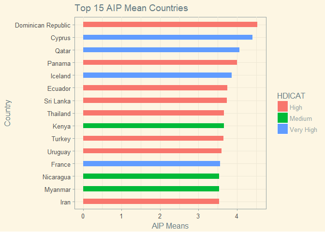

```r
#5c barchart of top 15 aip
top15aip <- aggregate(procrastcomb[, 63], by = list(procrastcomb$Countryres, procrastcomb$HDICAT), mean, na.rm=TRUE)
colnames(top15aip) <- c("Country", "HDICAT","AIPmean")
top15aip <- top15aip[order(-top15aip$AIPmean),]
# top15aip
#write table to csv(6c)
#setwd("C:/Users/jjschued/Documents")
write.table(top15aip, file = "top15aip.csv", col.names = TRUE, row.names = FALSE, sep =",")

#get the aip countries for very high hdi
top15aipvh <- subset(top15aip, HDICAT=='Very High' )
top15aipvh <-top15aipvh[order(-top15aipvh$AIPmean),]
#top15aipvh

top15aip <- top15aip[1:15,]
#top15aip

 ggplot(top15aip, aes(reorder(Country, AIPmean),AIPmean))+
 geom_bar(aes(fill=HDICAT), stat= "identity", width = .4, position = position_dodge(width = .9))+
 ggtitle("Top 15 AIP Mean Countries")+
 theme(plot.title = element_text(hjust = 0.5), legend.position="none",)+
 xlab("Country")+
 ylab("AIP Means")+
 theme(axis.text.y=element_text(hjust = .5, vjust = .5))+
 theme_solarized()+
 coord_flip()
```

WAM also requested supplemental analysis regarding how to target advertising for their series of trainings. Their interest was for ages, income, life satisfaction, and HDI categories of the targeted countries. The best relationship seems to be income to age. There is more income at older ages. Other relationships were not consequential. Therefore, it is suggested to examine targeting older individuals.

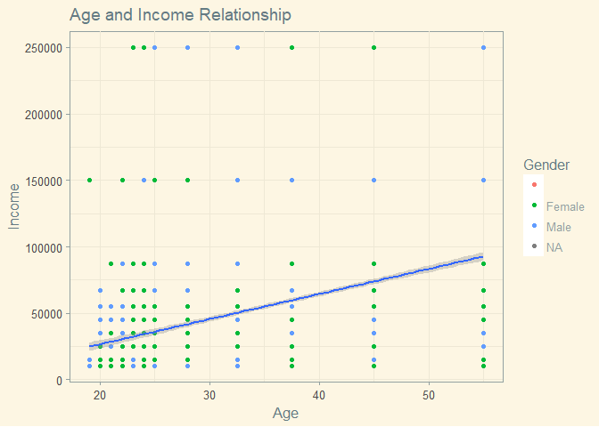

```r
 #5d relationship between age and income

 ggplot(procrastcomb, aes(x= procrastcomb$Age, y=procrastcomb$AnnualIncome))+
 geom_point(aes(col = procrastcomb$Gender))+
   guides(col=guide_legend(title="Gender"))+
geom_smooth(method=lm)+
 ggtitle("Age and Income Relationship")+
 theme(plot.title = element_text(hjust = 0.5), legend.position="none",)+
 xlab("Age")+
 ylab("Income")+
 theme(axis.text.y=element_text(hjust = .5, vjust = .5))+
 theme_solarized()
```

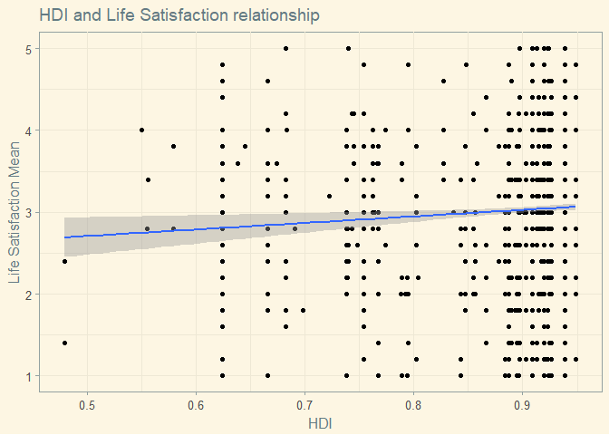

```r
 #5e relationship between Life satisfaction and HDI

 ggplot(procrastcomb, aes(x= procrastcomb$HDI, y=procrastcomb$swlsmean))+
 geom_point()+
geom_smooth(method=lm)+
 ggtitle("HDI and Life Satisfaction relationship")+
 theme(plot.title = element_text(hjust = 0.5), legend.position="none",)+
 xlab("HDI")+
 ylab("Life Satisfaction Mean")+
 theme(axis.text.y=element_text(hjust = .5, vjust = .5))+
 theme_solarized()
```

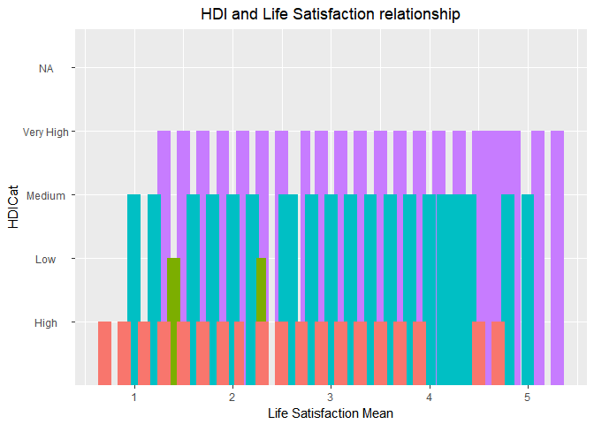

```r
 #HDI cat and life satisfaction

 ggplot(procrastcomb, aes(x= procrastcomb$swlsmean, y=procrastcomb$HDICAT))+
 geom_bar(aes(fill=HDICAT), stat= "identity", width = .4, position = position_dodge(width = .9))+
 ggtitle("HDI and Life Satisfaction relationship")+
 theme(plot.title = element_text(hjust = 0.5), legend.position="none",)+
 xlab("Life Satisfaction Mean")+
 ylab("HDICat")+
 theme(axis.text.y=element_text(hjust = .5, vjust = .5))
```

```r
 theme_solarized()
```

[output not shown]

[output cut: 376 more lines]

[output not shown]

In conclusion, though beyond the United States and a few other countries sample sizes are small the results suggest that there are markets that warrant additional analysis outside the scope of this project. Those include: central Europe, Hong Kong, and Qatar. Further surveys of employment age individuals should be gathered for all HDI Category-Very High to make better decisions about placement of their centers. It is important to place the centers in high-income areas in order to maximize exposure to customers with disposable income.